# Disaggregating Time-Series with Many Indicators: An Overview of the DisaggregateTS Package

Low-frequency time-series (e.g., quarterly data) are often treated as benchmarks for interpolating to higher frequencies, since they generally exhibit greater precision and accuracy in contrast to their high-frequency counterparts (e.g., monthly data) reported by governmental bodies. An array of regression-based methods have been proposed in the literature which aim to estimate a target high-frequency series using higher frequency indicators. However, in the era of big data and with the prevalence of large volumes of administrative data-sources there is a need to extend traditional methods to work in high-dimensional settings, i.e., where the number of indicators is similar or larger than the number of low-frequency samples. The package DisaggregateTS includes both classical regressions-based disaggregation methods alongside recent extensions to high-dimensional settings. This paper provides guidance on how to implement these methods via the package in R, and demonstrates their use in an application to disaggregating CO2 emissions.

Luke Mosley (Lancaster University) , Kaveh Salehzadeh Nobari (Imperial College LondonLondon School of Economics and Political Science) , Giuseppe Brandi (Imperial College LondonNortheastern University London) , Alex Gibberd (Lancaster University)  
2024-12-31

## 1 Introduction

Economic and administrative data, such as recorded surveys and consensus, are often disseminated by international governmental agencies at low or inconsistent frequencies, or irregularly-spaced intervals. To aid the forecasting of the evolution of the dynamics of these macroeconomic and socioeconomic indicators, as well as their comparison with higher resolution indicators provided by international agencies, statistical agencies rely on signal extraction, interpolation and temporal distribution adjustments of the low-frequency data to provide high precision and uninterrupted historical data. Although, temporal distribution, interpolation and benchmarking are closely associated with one another, this article and its respective package (DisaggregateTS, Mosley and S. Nobari 2024), expend particular attention to interpolation and temporal distribution (disaggregation) techniques, where the latter is predicated on regression-based methods[^1]. These regression-based temporal distribution techniques rely on high-frequency indicators to estimate (relatively) accurate high-frequency data points. With the prevalence of large volume of high-frequency administrative data, a great body of literature pertaining to statistical and machine learning methods has been dedicated to taking advantage of these additional resources for forecasting purposes (see Fuleky 2019 for an overview of macroeconomic forecasting in the presence of big data). Additionally, one may wish to utilize these abundant indicators to generate high-frequency estimates of low-frequency time-series with greater precision. However, in high-dimensional linear regression models where the number of dimensions surpass that of the observations, consistent estimates of the parameters is not possible without imposing additional structure (see Wainwright 2019). Hence, this article and the package DisaggregateTS adapt recent contributions in high-dimensional temporal disaggregation (see Mosley et al. 2022) to extend previous work within this domain Sax and Steiner (2013) to high-dimensional settings.

As noted by Dagum and Cholette (2006), time-series data reported by most governmental and administrative agencies tend to be of low-frequency and precise, but not particularly timely, whereas their high-frequency counterparts seldom uphold the same degree of precision.

The aim of temporal distribution techniques is to generate high-frequency estimates that can track shorter term movements, than directly observable with the direct low-frequency observations. While interpolation problems are generally encountered in the context of stock series, where say, the quarterly value of the low-frequency series must coincide with the value of third month of the high-frequency data (of the same quarter), temporal distribution problems often concern flow series, where instead the value of the low-frequency quarterly series must agree with the sum (or weighted combination) of the values of the high-frequency months in that quarter. The latter approach is generally accomplished by identifying and taking advantage of a number of high-frequency indicators which are deemed to behave in a similar manner to the low-frequency series, and by estimating the high-frequency series through a linear combination of such indicators.

In the last few decades, a significant number of articles have been published within this domain—see Dagum and Cholette (2006) for a detailed review of these techniques. Notable studies within this context include the additive regression-based benchmarking methods of Denton (1971) and Chow and Lin (1971), Chow and Lin (1976), as well as those proposed by Fernández (1981) and Litterman (1983) in the presence of highly persistent error processes. More recently these methods have been extended to the high-dimensional setting by Mosley et al. (2022), where prior information on the structure of the linear regression model is used to enable estimation, and better condition the regression problem. Specifically, this is accomplished by least absolute shrinkage and selection operator (LASSO hereafter) proposed by Tibshirani (1996), which in principle selects an appropriate model by penalizing the coefficients (in scale) of the high-dimensional regression, in effect discarding the irrelevant indicators from the model. In what follows, we demonstrate how to apply these methods using DisaggregateTS to easily estimate high-frequency series of interest.

The remainder of the paper is organized as follows: Section 2 presents the methodologies behind key temporal disaggregation techniques included in the DisaggregateTS package, along with their extensions to high-dimensional settings. Section 3 introduces the DisaggregateTS package and highlights its key functions. Sections 4 and 5 provide examples based on simulations (using a function in the package that generates synthetic data) and empirical data to demonstrate the package’s functionality. Finally, Section 6 concludes the paper.

## 2 Sparse temporal disaggregation

### 2.1 Classical regression-based techniques

The data in figures 1 and 2 are generated using the `TempDisaggDGP()` function from the DisaggregateTS package, representing simulated stock and flow data. For the simulated stock data (Figure 1, each quarter’s low-frequency data should match the first month’s value of the corresponding high-frequency series, denoted with red dots. For the simulated flow data (Figure 2, the quarterly figures should equal the sum of the sub-quarterly values

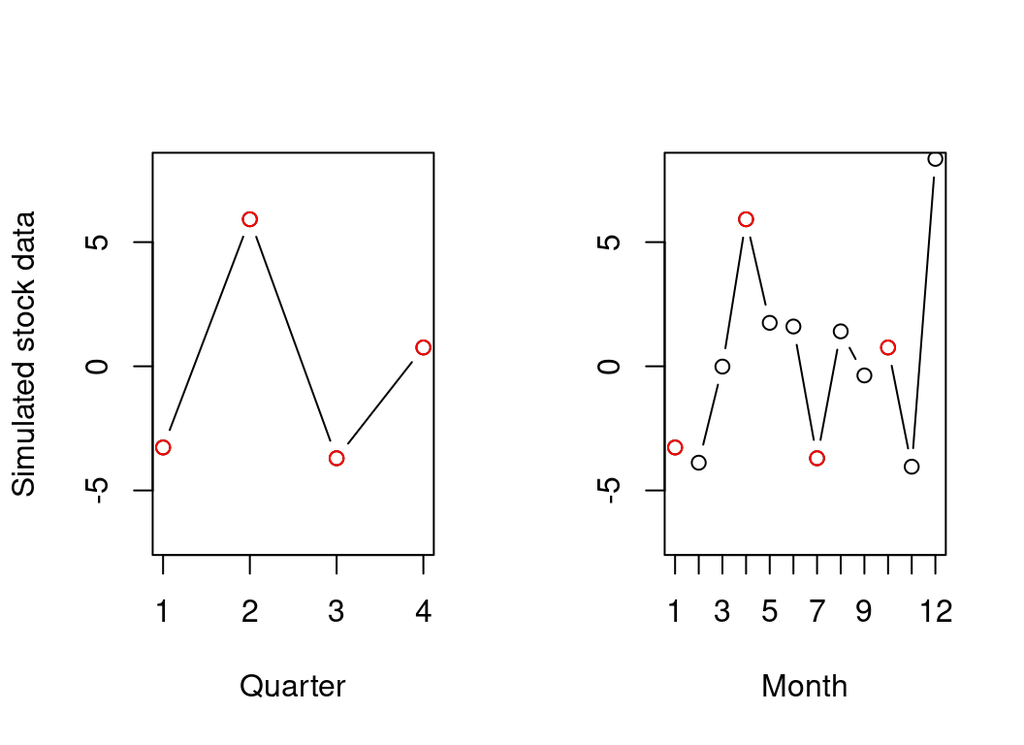

Figure 1: Quarterly and monthly simulated stock data

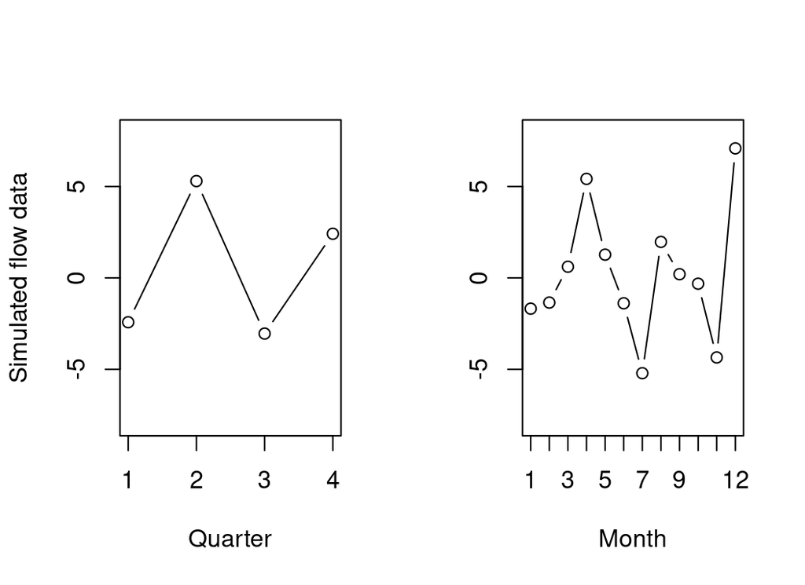

Figure 2: Quarterly and monthly simulated flow data

Suppose we observe a low-frequency series, say, quarterly GDP, encoded as the vector $\mathbf{y}_q\in \mathbb{R}^n$, containing $n$ quarterly observations. We desire to disaggregate this series to higher frequencies (say monthly), where the disaggregated series is denoted $\mathbf{y}_m\in \mathbb{R}^p$, with $p=3n$. Furthermore, we wish that the disaggregated series be temporally consistent without exhibiting any jumps between quarters (see Section 3.4 of Dagum and Cholette 2006 for examples of such inconsistencies between the periods). The challenge is to identify an approach that distributes the variation between each observed quarterly point to the monthly level. A method that has been extensively studied in the literature concerns finding high-frequency (e.g., monthly) indicator series that are thought to exhibit similar inter-quarterly movements as the low-frequency variable of interest. Let us denote a set of $p$ observations from these $d$ indicators as the matrix $\mathbf{X}_m\in \mathbb{R}^{p\times d}$. A classical approach to provide high-frequency estimates is the regression-based temporal disaggregation technique proposed by Chow and Lin (1971) whereby the unobserved monthly series $\mathbf{y}_m$ are assumed to follow the regression:
$$\begin{equation}
\mathbf{y}_m=\mathbf{X}_m\beta+\mathbf{u}_m,\quad \mathbf{u}_m\sim N(\mathbf{0}_m,\mathbf{V}_m)
\tag{1}
\end{equation}$$
where $\beta \in\mathbb{R}^d$ is a vector of regression coefficients to be estimated (noting that $\mathbf{X}_m$ may contain deterministic terms) and $\mathbf{u}_m\in \mathbb{R}^p$ is a vector of residuals. Chow and Lin (1971) assume that $\mathbf{u}_m$ follows as AR(1) process of the form $u_t=\rho u_{t-1}+\varepsilon_t$ with $\varepsilon_t\sim N(0,\sigma^2)$ and $\lvert \rho\rvert <1$. The assumption of stationary residuals allows for a cointegrating relationship between $\mathbf{y}_m$ and $\mathbf{X}_m$ when they are integrated of the same order. Thus, the covariance matrix has a well-known Toeplitz structure as follows:
$$\begin{equation}
\mathbf{V}_m=\frac{\sigma^2}{1-\rho^2}
\begin{pmatrix}
1 & \rho &\cdots & \rho^{p-1}\\
\rho & 1 &\cdots & \rho^{p-2}\\
\vdots&\vdots&\ddots&\vdots \\
\rho^{p-1} & \rho^{p-2} &\cdots & 1\\
\end{pmatrix}
\end{equation}$$
where $\rho$ and $\sigma$ are unknown parameters that need to be estimated. The dependent variable $\mathbf{y}_m$ in (1) is unobserved, hence the regression is premultiplied by the $n\times p$ aggregation matrix $\mathbf{C}$, where:
$$\begin{align}
\begin{split}
\mathbf{C}&=\mathbf{I}_n\otimes (1,1,1)\\
&=
\begin{pmatrix}
1&1&1&0&0&0&0&\cdots &0\\
0&0&0 & 1&1&1&0&\cdots &0\\
\vdots&\vdots&\vdots & &\ddots&\ddots&\ddots&\vdots &\vdots\\
0&\cdots&0&0&0&0&1&1 &1
\end{pmatrix}_{n\times p}
\end{split}
\tag{2}
\end{align}$$
where $\otimes$ is the Kronecker operator, and the vector of ones in (2) is used for flow data (e.g., GDP), such that the sum of the monthly GDPs coincides with its quarterly counterpart[^2]. The premultiplication yields the quarterly counterpart of (1):
$$\begin{equation}
\mathbf{C}\mathbf{y}_m=\mathbf{C}\mathbf{X}_m\beta+\mathbf{C}\mathbf{u}_m,\quad \mathbf{C}\mathbf{u}_m\sim N(\mathbf{C}\mathbf{0}_m,\mathbf{C}\mathbf{V}_m\mathbf{C}^{\top}).
\end{equation}$$
The GLS estimator for $\beta$ is thus expressed as follows:
$$\begin{align}
\hat{\beta}=&\arg\min_{\beta\in\mathbb{R}^d}\left\{\Big\lVert \mathbf{V}_q^{-\frac{1}{2}}(\mathbf{y}_q-\mathbf{X}_q\beta)\Big\rvert_2^2\right\}
\tag{3}\\
=&\left(\mathbf{X}_q^{\top}\mathbf{V}_q^{-1}\mathbf{X}_q\right)^{-1}\mathbf{X}_q^{\top}\mathbf{V}_q^{-1}\mathbf{y}_q
\tag{4}
\end{align}$$
where $\mathbf{X}_q=\mathbf{CX}_m$, $\mathbf{y}_q=\mathbf{Cy}_m$ and $\mathbf{V}_q=\mathbf{C}\mathbf{V}_m\mathbf{C}^{\top}$. Note that estimating $\beta$ requires the knowledge of the unknown parameters $\sigma$ and $\rho$ in $\mathbf{V}_m$ which are unknown. We employ the profile-likelihood maximization technique of Bournay and Laroque (1979), which involves first estimating $\hat{\beta}$ and $\mathbf{V}_q$ conditional on a given value of $\rho$, and maximizing the log-likelihood function by conducting a grid search over $\rho \in (-1, 1)$ for the autoregressive parameter. However, in practical applications, including well-known implementations such as the tempdisagg package and the `Gretl` econometric software Cottrell and Lucchetti (2023), the grid search is often restricted to $\rho \in [0, 1)$, reflecting a non-negative constraint on the autoregressive parameter. Our method is specifically designed to search within $\rho \in [0, 1)$, reflecting this non-negative constraint.

Chow and Lin (1971) show the optimal solution is obtained by:

$$\begin{equation}
\hat{\mathbf{y}}_m=\mathbf{X}_m\hat{\beta}+\hat{\mathbf{V}}_m\mathbf{C}\hat{\mathbf{V}}_q^{-1}\left(\mathbf{y}_q-\mathbf{X}_q\hat{\beta}\right),
\end{equation}$$
where $\mathbf{X}_m\hat{\beta}$ is the conditional expectation of $\mathbf{y}_m$ given $\mathbf{X}_m$ and the estimate of the monthly residuals are obtained by disaggregating the quarterly residuals $\mathbf{y}_q-\mathbf{X}_q\hat{\beta}$ to attain temporal consistency between $\hat{\mathbf{y}}_m$ and $\mathbf{y}$.

Other variants of the regression-based techniques include those proposed by Denton (1971), Fernández (1981), Litterman (1983), and Cholette (1984), with the latter two addressing scenarios where $\mathbf{y}_m$ and $\mathbf{X}_m$ are not cointegrated. Although these traditional techniques are included in the DisaggregateTS package, a comprehensive overview of different temporal disaggregation techniques and distribution matrices can be found in Table 2 of Sax and Steiner (2013). The tempdisagg package implements several standard methods for temporal disaggregation, each with distinct approaches for estimating high-frequency series. These include the Denton, Denton-Cholette, Chow-Lin, fernández, and Litterman methods. As summarized in Table 2 of Sax and Steiner (2013), Denton and Denton-Cholette focus on movement preservation, while regression-based methods like Chow-Lin, fernández, and Litterman perform generalized least squares regressions on the low-frequency series using one or more high-frequency indicators. We have implemented the Chow-Lin method with a non-negative autoregressive parameter, constrained within the range $[0, 1)$, following the approach of Bournay and Laroque (1979) and Cottrell and Lucchetti (2023). This offers flexibility in different disaggregation scenarios.

### 2.2 Extension to high-dimensional settings

The shortcoming of Chow and Lin (1971) becomes evident in data-rich environments, where the number of indicators $d\gg n$ surpass that of the time-stamps for the low-frequency data. Let us once again recall the GLS estimator (4). When $d<n$ and the columns of $\mathbf{X}_q^{\top}\mathbf{V}_q^{-1}\mathbf{X}_q$ are independent, the estimator is well-defined. However, when $d>n$, the matrix is rank-deficient - i.e., $\text{rank}(\mathbf{X}_q^{\top}\mathbf{V}_q^{-1}\mathbf{X}_q)\leq \min(n,d)$, the matrix $\mathbf{X}_q^{\top}\mathbf{V}_q^{-1}\mathbf{X}_q$ has linearly dependent columns, and thus is not invertible. In moderate dimensions, where $d\approx n$, $\mathbf{X}_q^{\top}\mathbf{V}_q^{-1}\mathbf{X}_q$ has eigenvalues close to zero, leading to high variance estimates of $\hat{\beta}$.

Mosley et al. (2022) resolve this problem by adding a regularizing penalty (e.g., $\ell_1$ regularizer) onto the GLS cost function (3):
$$\begin{equation}
\hat{\beta}(\lambda_n\mid\rho)=\arg\min_{\beta\in\mathbb{R}^d}\left\{\Big\lVert \mathbf{V}_q^{-\frac{1}{2}}(\mathbf{y}_q-\mathbf{X}_q\beta)\Big\rVert_2^2+\lambda_n\lVert \beta\rVert_1\right\}.
\tag{5}
\end{equation}$$

Unlike the GLS estimator (4), the regularized estimator corresponding to the cost function (5) is a function of $\lambda_n$ and the autoregressive parameter $\rho$. Henceforth, it is important to nominate the most suitable $\lambda_n$ and $\rho$ to correctly recover the parameters. In (5), we denote the estimator as $\hat{\beta}(\lambda_n\mid\rho)$ to highlight that the solution paths of the estimator for different values of $\lambda_n$, say, $\lambda_n^{(1)},\lambda_n^{(2)},\cdots,\lambda_n^{(k)}$ are generated for (i.e. conditional on) a fixed $\rho$. The solution paths are obtained using the LARS algorithm proposed by Efron et al. (2004), the benefits of which have been extensively discussed in Mosley et al. (2022).

LASSO estimators inherently exhibit a small bias, such that $\lVert \hat{\beta}\rVert_2^2\leq \lVert \beta^*\rVert_2^2$, where $\beta^*$ denotes the true coefficient vector. To alleviate this issue, Mosley et al. (2022) further follow Belloni and Chernozhukov (2013), by performing a refitting procedure using least squares re-estimation. The latter entails generating a new $n\times d^{(l)}$ sub-matrix $\mathbf{X'}_q$, where $d^{(l)}\leq d$ from the original $n\times d$ matrix $\mathbf{X}_q$, with $\mathbf{X'}_q$ corresponding to the columns of $\mathbf{X}_q$ supported by $\hat{\beta}(\lambda_n^{(l)}\mid\rho)$, for solutions $l=1,\cdots,k$ obtained from the LARS algorithm[^3]. We then perform a usual least squares estimation on $(\mathbf{y}_q,\mathbf{X'}_q)$ to obtain debiased solution paths for each $\lambda_n^{(l)}$.

Finally, Mosley et al. (2022) choose the optimal estimate from $\hat{\beta}(\lambda_n^{1}\mid \rho),\cdots,\hat{\beta}(\lambda_n^{k}\mid \rho)$ using the Bayesian Information Criterion (BIC hereafter) proposed by Schwarz (1978). The motivation for nominating this statistic over resampling methods, such as cross-validation or bootstrapping techniques, stems from the small sample size in the low-frequency observations. The optimal regularization is chosen conditional on $\rho$ according to
$$\begin{equation}
\hat{\lambda}_n(\rho)={\arg\min}_{\lambda_n(\rho)\in\{\lambda_n^{(1)}(\rho),\cdots,\lambda_n^{(k)}(\rho)\}}\left\{-2\mathcal{L}\left(\hat{\beta}(\lambda_n\mid \rho),\hat{\sigma}^2\right)+\log(n)K_{\lambda_n(\rho)}\right\},
\tag{6}
\end{equation}$$
where $K_{\lambda_n(\rho)}=\lvert \{r:(\hat{\beta}(\lambda_n\mid \rho)_r\neq 0)\}\rvert$ is the degrees of freedom and $\mathcal{L}(\hat{\beta}(\lambda_n\mid \rho),\hat{\sigma}^2)$ is the log-likelihood function of the GLS regression (4), which in the presence of Gaussian errors, is given by:
$$\begin{equation}
\mathcal{L}(\hat{\beta},\hat{\sigma}^2)=-\frac{n}{2}\log(2\pi)-\frac{n}{2}\log(\sigma^2)-\frac{1}{2}\log(\lvert \mathbf{S}\rvert)-\frac{1}{2\sigma^2}(\mathbf{y}_q-\mathbf{X}_q\beta)^\top(\mathbf{y}_q-\mathbf{X}_q\beta),
\end{equation}$$
where $\lvert \mathbf{S}\rvert$ is the determinant of the Toeplitz matrix $\mathbf{S}$ depending on $\rho$, such that $\mathbf{V}_q=\sigma^2\mathbf{S}$ (recalling that $\mathbf{V}_q=\mathbf{C}\mathbf{V}_m\mathbf{C}^{\top}$).

## 3 The package

In this Section, we showcase the main functions that has been included in the DisaggregateTS package. Following Sax et al. (2023), we first introduce the main function of the package and it its features, and subsequently we will showcase other functions that allow the practitioner to conducting simulations and analyses.

### 3.1 Functions

The main function of the package which performs the sparse temporal disaggregation method proposed by Mosley et al. (2022) is `disaggregate()`. This function is of the following form:

```r
disaggregate(Y, X, aggMat, aggRatio, method, ...)
```

where the first argument of the function, `Y`, corresponds to the $n\times 1$ vector of low-frequency series $\mathbf{y}_q$ that we wish to disaggregate, and the second argument, `X`, is the $p\times d$ matrix of high-frequency indicator series $\mathbf{X}_m$. In the event that there is no input `X`, the disaggregation matrix $\mathbf{X}_m$ is replaced with an $n\times 1$ vector of ones.

The argument `aggMat` coincides with the aggregation matrix $\mathbf{C}$ in (2), and it has been set to `"sum"` by default, rendering it suitable for flow data. Alternative options include `"first"`, `"last"` and `"average"`. The aggregation (distribution) matrices that are utilized in this function are summarized in table 2 of Sax et al. (2023).

The argument `aggRatio` has been set to `4` by default, which represents the ratio of annual to quarterly data. In general, this argument should be set to the ratio of the high-frequency to low-frequency series. For instance, in the examples considered in the preceding Sections, we had considered quarterly data as the low-frequency series, and monthly data as its high-frequency counterpart. Thus, in this setting `aggRatio = 3`. At first glance, the presence of the `aggRatio` argument may seem redundant. However, if $n\geq n_l\times \text{aggRatio}$, then extrapolation is done up to $n$.

Finally, the argument `method` refers to the method of disaggregation under consideration. This argument has been set to `"Chow-lin"` method by default, which is the classical regression-based disaggregation technique introduced in Section 2.1. Other classical low-dimensional options include `"Denton"`, `"Denton-Cholette"`, `"fernandez"`, and `"Litterman"`, where these techniques have been extensively discussed in Dagum and Cholette (2006) and Sax and Steiner (2013). The main contribution of this package stems from the `"spTD"` and `"adaptive-spTD"` options pertaining to sparse temporal disaggregation and adaptive sparse temporal disaggregation, which are Mosley et al. (2022)’s high-dimensional extension of the regression-based techniques proposed by Chow and Lin (1971). In a high-dimensional regression, the adaptive LASSO is relevant when, for instance, the columns of the design matrix $\mathbf{X}$ exhibit multicollinearity, and the *Irrepresentability Condition* (IC hereafter) is violated (see Zou 2006 for details). In such settings, the regularization parameter $\lambda$ does not satisfy the oracle property, which can lead to inconsistent variable selection. The adaptive counterpart of the regularized GLS cost function (5), can be expressed as follows:
$$\begin{equation}
\hat{\beta}(\lambda_n\mid\rho)=\arg\min_{\beta\in\mathbb{R}^d}\left\{\Big\lVert \mathbf{V}_q^{-\frac{1}{2}}(\mathbf{y}_q-\mathbf{X}_q\beta)\Big\rVert_2^2+\lambda_n\sum_{j=1}^{d}\frac{\lvert \beta_j\rvert}{\lvert \hat{\beta}_{\text{init},j}\rvert}\right\},
\tag{7}
\end{equation}$$
where $\hat{\beta}_{\text{init},j}$ is an initial estimator, predicated on $\hat{\beta}(\hat{\rho})$ from the regularized (LASSO) temporal disaggregation. See Mosley et al. (2022), for the details of the proposed methodology, and Zou (2006) and Van de Geer et al. (2011) to yield variable selection consistency using the OLS estimator and LASSO as $\hat{\beta}_{\text{init},j}$ when the IC condition is violated.

The second main function of the DisaggregateTS package is `TempDisaggDGP()`, which generates synthetic data that can be used for conducting simulations using the `disaggregate()` function. The main arguments of this function are as follows:

```r
TempDisaggDGP(n_l, n, aggRatio, p, beta, sparsity, method, aggMat, rho, ...)
```

where the first argument corresponds to the size of low-frequency series and `n` to that of the high-frequency series. Moreover, `aggRatio` and `aggMat` are defined as before, in turn representing the ratio of the high-frequency to low-frequency series, as well as the aggregation matrix (2). A minor difference in the DGP function is that if $n\geq n_l\times \text{aggRatio}$, then the last $n-\text{aggRatio}\times n_l$ columns of the aggregation matrix are set to zero, such that $Y$ is observed only up to $n_l$. Argument `p` sets the dimensionality of high-frequency series (set to $1$ by default), `beta` which has been set to `1` by default is the positive and negative elements of the coefficient vector, `sparsity` is the sparsity percentage of the coefficient vector, and `rho` is the autocorrelation of the error terms, which has been set to `0` by default. Finally, the `method` argument determines the data generating process of the error terms, corresponding to methods discussed earlier in this Section.

A number of optional arguments included in the function determine the mean vector and the standard deviation of the design matrix, as well as options such a setting seed for running the simulations, where the design matrix and the coefficient vectors are fixed.

In what follows, we showcase a simple example of the function and its respective outputs:

```r
# Generate low-frequency quarterly series and its high-frequency monthly counterpart
SynthethicData <- TempDisaggDGP(n_l = 2,
                                n = 6,
                                aggRatio = 3,
                                p = 6,
                                beta = 0.5,
                                sparsity = 0.5,
                                method  = 'Chow-Lin',
                                rho = 0.5)
```

In the example above, we generate low-frequency series $\mathbf{y}_q\in \mathbb{R}^2$ corresponding to two quarters, and consequently, its high-frequency monthly counterpart $\mathbf{y}_m \in \mathbb{R}^{6}$. It is further assumed that the data is generated using six monthly indicators - i.e., $\mathbf{X}^{6\times 6}_m$, with a coefficient vector $\beta\in \mathbb{R}^6$, where $\beta_j \in \{-0.5, 0, +0.5\}$. Since, the sparsity argument is set to $0.5$, only half of $\beta$’s elements are non-zero. Finally, the error vector $\mathbf{u}_m$ is assumed to follow the AR($1$) structure of Chow and Lin (1971), with an autocorrelation parameter of $\rho=0.5$.